# Análise de Gastos de Deputados: Suas Perguntas

Daniyel Rocha

7 de Setembro de 2018

# Sobre os dados

As informações utilizadas são referentes aos gastos com a CEAP (cota para o exercício da atividade parlamentar). Esses valores representam uma cota única mensal, destinada a custear os gastos dos deputados federais exclusivamente vinculados ao exercício da atividade parlamentar. Os dados foram coletados do site de transparência da Câmara, tratados, e podem ser baixados neste [link](https://canvas.instructure.com/courses/1402758/files/67618888/download?verifier=ibyou5PYo9aaFgRaefc0keYkHhkQ2EqIArdmI1bq&wrap=1).

Outros dados que fazem parte da análise são os valores com os limites de CEAP para cada estado. O valor máximo mensal da cota depende da unidade da federação que o deputado representa. Essa variação ocorre por causa das passagens aéreas e está relacionada ao valor do trecho entre Brasília e o Estado que o deputado representa. Os dados podem ser baixados [aqui](https://canvas.instructure.com/courses/1402758/files/67618889/download?verifier=vfi4jwcg26IVtelxRY7Sm5RnhrAuKcNrOrw2Yt6Y).

A seguir, fazemos a leitura desses dados e observamos uma pequena amostra.

```r
dados <- read_csv("../data/dadosCEAP.csv", progress = FALSE)
limite_CEAP <- read_csv("../data/limiteMensalCEAP.csv")
dados$valorGlosa <- as.numeric(sub(",", ".", dados$valorGlosa, fixed = TRUE))

glimpse(dados)
```

```
## Observations: 963,452
## Variables: 13
## $ nomeParlamentar <chr> "ABEL MESQUITA JR.", "ABEL MESQUITA JR.", "ABE...
## $ idCadastro      <int> 178957, 178957, 178957, 178957, 178957, 178957...
## $ sgUF            <chr> "RR", "RR", "RR", "RR", "RR", "RR", "RR", "RR"...
## $ sgPartido       <chr> "DEM", "DEM", "DEM", "DEM", "DEM", "DEM", "DEM...
## $ tipoDespesa     <chr> "MANUTENÇÃO DE ESCRITÓRIO DE APOIO À ATIVIDADE...
## $ especDespesa    <chr> NA, NA, NA, NA, NA, "Veículos Automotores", "V...
## $ fornecedor      <chr> "COMPANHIA DE AGUAS E ESGOTOS DE RORAIMA", "CO...
## $ CNPJCPF         <chr> "05939467000115", "05939467000115", "023414700...
## $ tipoDocumento   <int> 0, 0, 0, 0, 0, 0, 0, 0, 0, 0, 0, 0, 0, 0, 0, 0...
## $ dataEmissao     <dttm> 2015-11-14, 2015-12-10, 2015-11-27, 2015-12-3...
## $ valorDocumento  <dbl> 165.65, 59.48, 130.95, 196.53, 310.25, 32.00, ...
## $ valorGlosa      <dbl> 0, 0, 0, 347, 0, 0, 0, 0, 0, 0, 0, 0, 0, 0, 0,...
## $ valorLíquido    <dbl> 165.65, 59.48, 130.95, 193.06, 310.25, 32.00, ...
```

## Quais são os principais gastos durante o recesso parlamentar?

> Provavelmente o principal gasto será relativo a viagens, já que nesse período é muito comum ocorrerem viagens de lazer.

O recesso parlamentar é o período em que os parlamentos não funcionam no Brasil, incluindo a câmara dos deputados. Esse período tem um total de 55 dias, com os trabalhos suspensos entre os dias de 23 de dezembro a 1º de fevereiro e de 18 a 31 de julho. Por conta das atividades parlamentares estarem suspensas, é plausível assumir que os gastos com a cota de exercício da atividade parlamentar não existam (ou sejam reduzidos). Na prática, as coisas não funcionam totalmente dessa maneira. Existe a chamada [Comissão Representativa do Congresso](http://www2.camara.leg.br/comunicacao/assessoria-de-imprensa/comissoes), que atua nesses períodos e, possivelmente, também faz uso do CEAP. Não existem muitas informações claras a respeito do que os parlamentares fazem no recesso, muito menos sobre a utilização do CEAP. Mais informações [aqui](http://www2.camara.leg.br/comunicacao/assessoria-de-imprensa/recesso-dos-deputados) e [aqui](https://plenarinho.leg.br/index.php/2018/01/26/o-que-e-o-recesso-parlamentar/).

Para responder essa pergunta, vamos primeiro filtrar as informações de gastos relativos as datas de recesso. Os dados correspondem aos recessos de final de ano de 2014 até o do meio do ano de 2017.

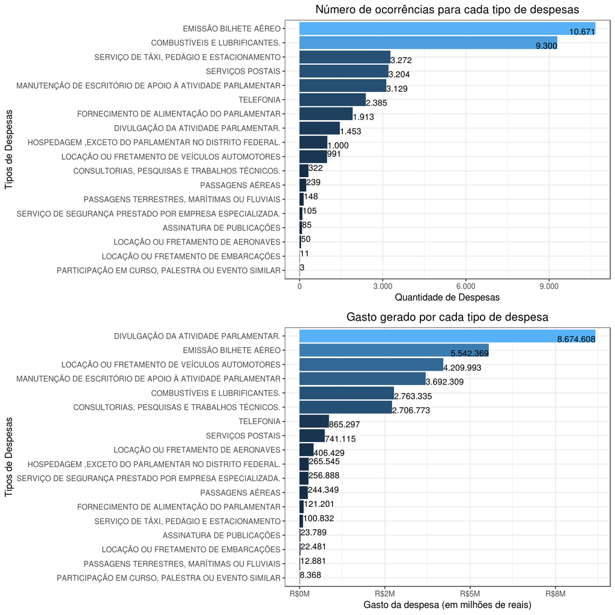

```r
dados_recesso <- dados %>%
  mutate(tipoDespesa = str_to_upper(tipoDespesa)) %>%
  mutate(dataEmissao = lubridate::as_date(dataEmissao)) %>%
  mutate(mes_dia = (month(dataEmissao)*100) + day(dataEmissao)) %>%
  filter(between(mes_dia,1223,1231) | between(mes_dia,101,102) | between(mes_dia,718,731)) %>%
  select(-mes_dia)

#dados_recesso %>%
#  filter(valorLíquido > 0) %>%
#  summarise(gastoTotal_recesso = sum(valorLíquido))

num_despesas_recesso <- dados_recesso %>%
  group_by(tipoDespesa) %>%
  summarise(n = n()) %>%
  arrange(desc(n))

gasto_despesas_recesso <- dados_recesso %>%
  filter(valorLíquido > 0) %>%
  group_by(tipoDespesa) %>%
  summarise(gasto = sum(valorLíquido)) %>%
  arrange(desc(gasto))

g1 <- num_despesas_recesso %>%
  ggplot(aes(x=reorder(tipoDespesa, n), y=n, fill=n)) +
  geom_bar(stat = "identity") +
  scale_y_continuous(labels = scales::number_format(big.mark = ".", decimal.mark = ",")) +
  geom_text(aes(label=scales::comma(n, big.mark = ".", decimal.mark = ","), vjust = 0.5, hjust = 0),
            size = 3.5, vjust="inward", hjust="inward") +
  coord_flip() +
  labs(x = "Tipos de Despesas", y = "Quantidade de Despesas") +
  ggtitle("Número de ocorrências para cada tipo de despesas") +
  guides(fill = FALSE) +
  theme(plot.title = element_text(hjust = 0.5))

g2 <- gasto_despesas_recesso %>%
  ggplot(aes(x=reorder(tipoDespesa, gasto), y=gasto, fill=gasto)) +
  geom_bar(stat = "identity") +
  scale_y_continuous(labels = scales::number_format(big.mark = ".", decimal.mark = ",", scale = 1/1000000, prefix = "R$", suffix = "M")) +
  geom_text(aes(label=scales::comma(gasto, big.mark = ".", decimal.mark = ","), vjust = 0.5, hjust = 0),
            size = 3.5, vjust="inward", hjust="inward") +
  coord_flip() +
  labs(x = "Tipos de Despesas", y = "Gasto da despesa (em milhões de reais)", fill = "Gasto (em R$)") +
  ggtitle("Gasto gerado por cada tipo de despesa") +
  guides(fill = FALSE) +
  theme(plot.title = element_text(hjust = 0.5))

grid.arrange(g1,g2)
```

Nesse período o gasto total gerado pelos parlamentares e pelas lideranças dos partidos foi em torno de 30 milhões de reais. Com base nos gráficos gerados, verificamos que, de fato, a emissão de bilhetes aéreos são os tipos de despesas que são mais frequentes durante as férias dos parlamentares. No entanto, essa despesa não gerou o maior gasto para o período: a divulgação de atividade parlamentar destacou-se como a despesa que gerou mais gastos com relação ao uso do CEAP pelos deputados, com cerca de 3 milhões de reais a mais de diferença em relação aos gastos com bilhetes aéreos, o segundo colocado.

Em função disso, muitas perguntas podem surgir a respeito desses gastos: qual o motivo de uma despesa tão alta com divulgação da atividade parlamentar? Qual o motivo do contribuinte arcar com uma despesa tão alta de passagens aéreas em um período de férias? Perguntas como essa evidenciam a importância da clareza com relação às razões que levam a esses gastos.

## Quais parlamentares geraram mais gastos com transporte mensalmente?

> Os deputados que são de estados distantes de Brasília provavelmente apresentam mais despesas com transporte, já que o deslocamento é mais difícil.

Essa pergunta exige que façamos algumas manipulações com os dados, neste caso iremos acrescentar a informação da região que o estado pertence, além de considerar que o gasto com total com transporte será definido pela soma de `COMBUSTÍVEIS E LUBRIFICANTES.`, `PASSAGENS AÉREAS`, `LOCAÇÃO OU FRETAMENTO DE VEÍCULOS AUTOMOTORES`, `LOCAÇÃO OU FRETAMENTO DE EMBARCAÇÕES`, `SERVIÇO DE TÁXI, PEDÁGIO E ESTACIONAMENTO`, `LOCAÇÃO OU FRETAMENTO DE AERONAVES` e `PASSAGENS TERRESTRES, MARÍTIMAS OU FLUVIAIS`. Feito isso, podemos agrupar os dados para obter o valor gasto mensalmente por cada parlamentar com transporte.

```r
#Qual o parlamentar que mais gasta com transporte (mensalmente)
#combustiveis, passagens, locação, serviço taxi

NORTE <- c("AM", "RO", "RR", "AC", "AP", "PA", "TO")
NORDESTE <- c("PI", "AL", "CE", "MA", "PE", "PB", "BA", "SE", "RN")
CENTRO_OESTE <- c("MS", "MT", "GO", "DF")
SUDESTE <- c("MG", "RJ", "SP", "ES")
SUL <- c("RS", "SC", "PR")

dados_transporte <- dados %>%
  mutate(tipoDespesa = str_to_upper(tipoDespesa)) %>%
  mutate(regiao = case_when(
    sgUF %in% NORTE ~ "NORTE",
    sgUF %in% NORDESTE ~ "NORDESTE",
    sgUF %in% CENTRO_OESTE ~ "CENTRO_OESTE",
    sgUF %in% SUL ~ "SUL",
    sgUF %in% SUDESTE ~ "SUDESTE"
  )) %>%
  filter(str_detect(tipoDespesa, "COMBUSTÍVEIS|PASSAGENS|LOCAÇÃO|TÁXI"))

parlamentar_mensal_transporte <- dados_transporte %>%
  filter(valorLíquido > 0) %>%
  mutate(mes = lubridate::month(dataEmissao), ano = lubridate::year(dataEmissao)) %>%
  group_by(nomeParlamentar, idCadastro, sgUF, regiao, mes, ano) %>%
  summarise(gasto_mensal = sum(valorLíquido)) %>%
  ungroup()

mediana_gasto_mensal_transporte <- parlamentar_mensal_transporte %>%
  group_by(nomeParlamentar, idCadastro, sgUF, regiao) %>%
  summarise(mediana_gasto = median(gasto_mensal)) %>%
  na.omit(idCadastro) %>%
  ungroup() %>%
  arrange(desc(mediana_gasto))

gasto_mensal_regiao <- parlamentar_mensal_transporte %>%
  filter(!is.na(regiao)) %>%
  group_by(regiao) %>%
  summarise(soma_gasto = sum(gasto_mensal)) %>%
  arrange(desc(soma_gasto)) %>%
  ungroup()
```

Como iremos comparar o gasto dos deputados ao longo de um período de tempo, iremos sumarizar esse gasto como a mediana dos gastos mensais. Além disso, as informações das regiões podem nos ajudar a entender melhor os motivos do gasto, uma vez que todos eles trabalham em Brasília e cada um tem um perfil de despesas com transporte diferente. A seguir geramos os gráficos para entender melhor os dados:

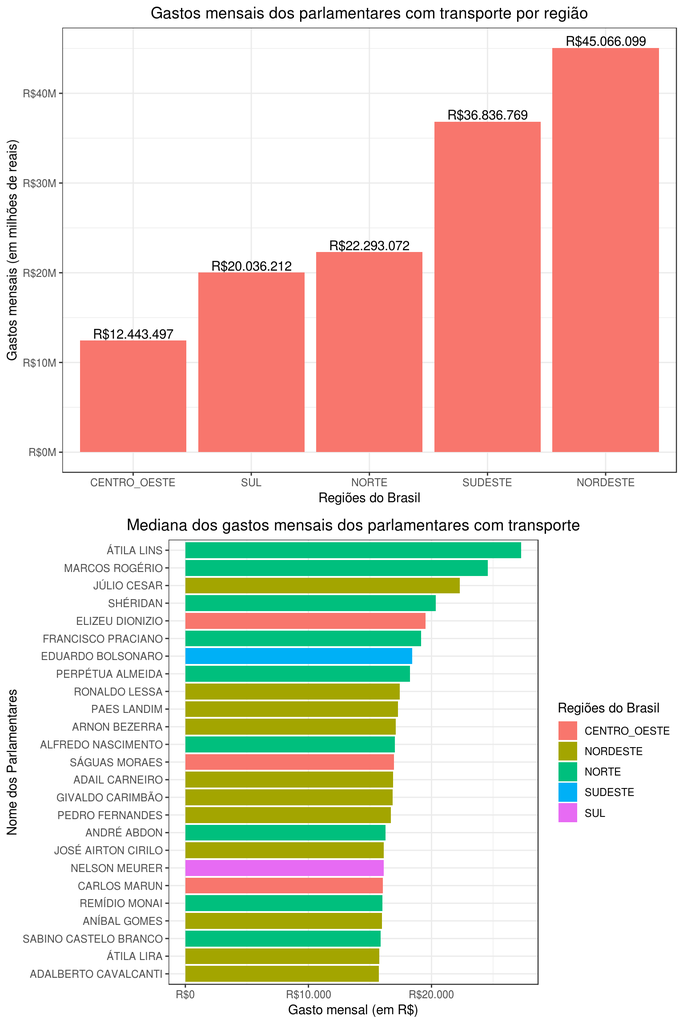

```r
t1 <- gasto_mensal_regiao %>%
  ggplot(aes(x=reorder(regiao,soma_gasto), y=soma_gasto, fill="#FF6666")) +
  geom_bar(stat = "identity") +
  geom_text(aes(label=scales::comma(soma_gasto, big.mark = ".", decimal.mark = ",", prefix = "R$"), vjust = -0.2)) +
  scale_y_continuous(labels = scales::number_format(big.mark = ".", decimal.mark = ",", scale = 1/1000000, prefix = "R$", suffix = "M")) +
  guides(fill = FALSE) +
  labs(x = "Regiões do Brasil", y = "Gastos mensais (em milhões de reais)") +
  ggtitle("Gastos mensais dos parlamentares com transporte por região") +
  theme(plot.title = element_text(hjust = 0.5))

#selecionando os 25 que mais gastaram c/ transporte
t2 <- mediana_gasto_mensal_transporte %>%
  head(25) %>%
  ggplot(aes(x=reorder(nomeParlamentar,mediana_gasto), y=mediana_gasto, fill=regiao)) +
  geom_bar(stat = "identity") +
  scale_y_continuous(labels = scales::number_format(big.mark = ".", decimal.mark = ",", prefix = "R$")) +
  coord_flip() +
  labs(fill = "Regiões do Brasil", x="Nome dos Parlamentares", y = "Gasto mensal (em R$)") +
  ggtitle("Mediana dos gastos mensais dos parlamentares com transporte") +
  theme(plot.title = element_text(hjust = 0.5))

grid.arrange(t1,t2)
```

Os gráficos acima nos permitem visualizar que o maior gasto por região é do Nordeste, que de fato é mais distante de Brasília. Além disso, podemos ver que entre os 25 deputados que mais gastam, muitos deles são da região Nordeste, além de muitos da região Norte.